# Individual Project Ixodes ricinus in Sweden

Devika Kuzhupadickal Sreekumar

2026-10-19

Assess the distribution for the tick ‘Ixodes ricinus’ in Sweden, produce a map and compare the predicted distribution for this species with the ECDC map.

**Tasks**

- Model compared to original assessment
- SDM based on another data set, with another model method and only in Sweden.
- Characterise uncertainty by model calibration where you change what data that is used (bootstrapping) and propagate to the SDM output.
- Summarise uncertainty in selected regions on the edge of the distribution
- Use your assessment to conclude if there is a concern to get bitten by a tick and become infected with tick-borne encephalitis virus (TBE). Provide your conclusion with an assessment of overall uncertainty, one per country.

**Approach**

We use species data and habitat suitability data (climate data and land cover information) in a species distribution model (SDM).

The modelling method is **Maxnet**, an R implementation of maximum entropy modelling. It compares the conditions at recorded locations with conditions available across the study area and it does **not** need confirmed absences.

| Choose this key | Swedish name | Scientific name | Records supplied |
| --- | --- | --- | --- |
| `"common_tick"` | Common tick | *Ixodes ricinus* | 2275 |

**Quantity of interest:** p(inf | forest, region), the probability to be infected when out in a forest in the selected region (here Örebro län, NUTS3 code SE124).

## 1. Setup

```r
knitr::opts_chunk$set(echo = TRUE, message = FALSE, warning = FALSE,
                      fig.align = "center", out.width = "90%")

packages <- c("SDMtune", "terra", "sf", "ggplot2", "fitdistrplus")
missing <- packages[!vapply(packages, requireNamespace, logical(1),
                            quietly = TRUE)]
if (length(missing)) {
  stop("Install these R packages: ", paste(missing, collapse = ", "))
}

library(SDMtune)
library(terra)
library(sf)
library(ggplot2)
library(fitdistrplus)
set.seed(42)                                      # repeatable thinning, background sampling and bootstraps
n_iter  <- 2000                                   # bootstrap / Monte Carlo iterations
q_probs <- c(0.05, 0.25, 0.50, 0.75, 0.95)        # quantiles used in the whole assessment
q_names <- c("P5", "P25", "P50", "P75", "P95")
```

## 2. Species data

The species data is from artportalen.se for *Ixodes ricinus*, period 2000 - 2026, around 2275 tick observations for Sweden.

```r
species_key <- "common_tick"

species <- list(
  common_tick = list(file = "Tick_data.csv",
                     common = "Common tick",
                     latin = "Ixodes ricinus")
)

stopifnot(species_key %in% names(species))
tick <- species[[species_key]]
out_dir <- file.path("results", species_key)
dir.create(out_dir, recursive = TRUE, showWarnings = FALSE)
tick$latin
```

```
## [1] "Ixodes ricinus"
```

## 3. Climate and land cover data (habitat suitability data)

We use three CHELSA variables: mean annual temperature (**BIO1**), annual precipitation (**BIO12**) and precipitation seasonality (**BIO15**). Land cover comes from CORINE Land Cover (CLC). Sweden is the study area, neighbouring countries are cropped out.

```r
nuts_all <- terra::vect("data/NUTS.gpkg")                                    # Europe wide data
nuts3_se <- nuts_all[nuts_all$CNTR_CODE == "SE" & nuts_all$LEVL_CODE == 3, ] # Sweden, level 3 (län)
stopifnot(nrow(nuts3_se) == 21)                                              # Sweden has 21 NUTS3 regions

terra::writeVector(nuts3_se, "data/Sweden_NUTS3.gpkg", overwrite = TRUE)

terra::plot(nuts3_se, col = "#A5CCC0", border = "#294851", main = "Sweden NUTS 3 (län)")
terra::text(nuts3_se, "NUTS_ID", cex = 0.6)
```

```r
landcover <- terra::rast("data/LC_Corine.tif")
nuts3_se  <- terra::vect("data/Sweden_NUTS3.gpkg")

terra::crs(landcover) <- terra::crs(nuts3_se)                  # same coordinate system

lc_sweden <- terra::mask(terra::crop(landcover, nuts3_se), nuts3_se)

terra::writeRaster(lc_sweden, "data/LC_Sweden_cropped.tif",
                   overwrite = TRUE, datatype = "INT2U")

terra::plot(lc_sweden, main = "Land cover, Sweden")
terra::lines(nuts3_se, col = "black")

terra::crs(lc_sweden, describe = TRUE)$name                    # should say ETRS89-extended / LAEA Europe
```

```r
inputs <- c("data/climate_sweden.tif",
            "data/LC_Sweden_cropped.tif",
            "data/Sweden_NUTS3.gpkg",
            "data/Tick_data.csv")

if (!all(file.exists(inputs))) {
  stop("Missing input files: ", paste(inputs[!file.exists(inputs)], collapse = ", "))
}
```

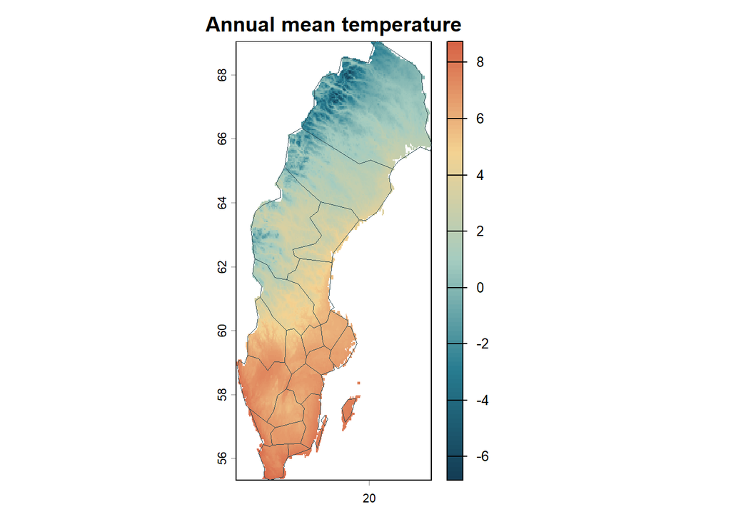

```r
climate  <- terra::rast("data/climate_sweden.tif")
nuts3_se <- terra::vect("data/Sweden_NUTS3.gpkg")

stopifnot(terra::nlyr(climate) == 3)
names(climate) <- c("bio1", "bio12", "bio15")

# the raster is in lon/lat and the regions in metres, so transform the regions to lon/lat
nuts3_clim <- terra::vect(sf::st_transform(sf::st_as_sf(nuts3_se), 4326))

cols <- grDevices::colorRampPalette(
  c("#143D55", "#287D91", "#A5CCC0", "#F4D392", "#D76346")
)(100)

terra::plot(climate[[1]], col = cols, main = "Annual mean temperature")
terra::lines(nuts3_clim, col = "#294851", lwd = 0.6)
```

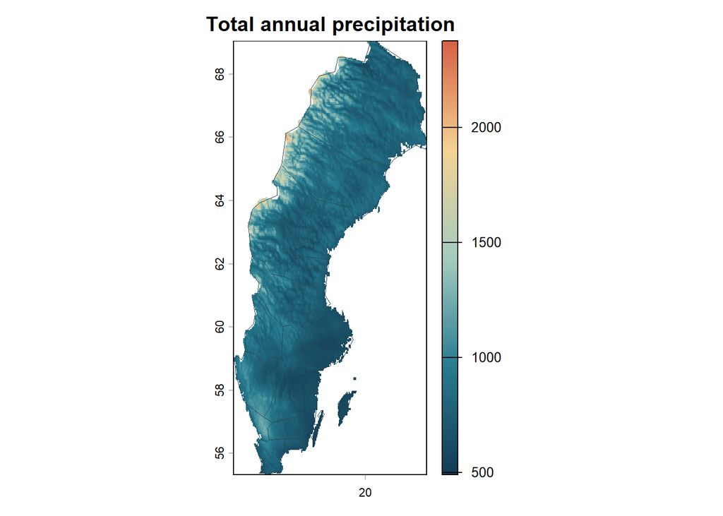

```r
terra::plot(climate[[2]], col = cols, main = "Total annual precipitation")
terra::lines(nuts3_clim, col = "#294851", lwd = 0.6)
```

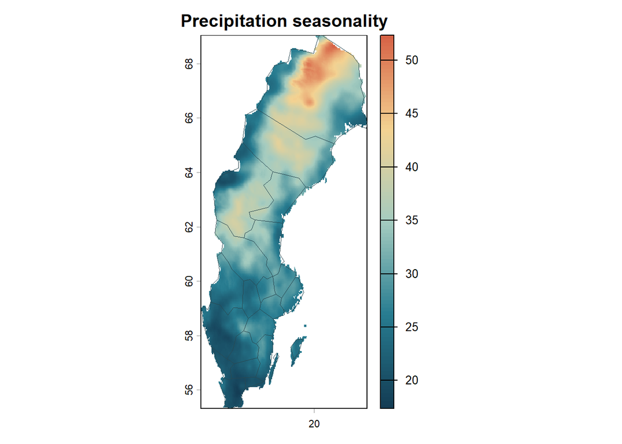

```r
terra::plot(climate[[3]], col = cols, main = "Precipitation seasonality")
terra::lines(nuts3_clim, col = "#294851", lwd = 0.6)
```

```r
landcover <- terra::rast("data/LC_Sweden_cropped.tif")
nuts3_se  <- terra::vect("data/Sweden_NUTS3.gpkg")

names(landcover) <- "landcover"
landcover[landcover %in% c(48, 255)] <- NA        # NODATA / unclassified codes become NA
```

```
## |---------|---------|---------|---------|=========================================                                          |---------|---------|---------|---------|=========================================
```

```r
terra::freq(landcover)
```

```
##    layer value    count
## 1      1     1     3728
## 2      1     2   429874
## 3      1     3    76193
## 4      1     4     6032
## 5      1     5     3168
## 6      1     6    14599
## 7      1     7    17911
## 8      1     8    10616
## 9      1     9     1152
## 10     1    10    29138
## 11     1    11    56343
## 12     1    12  2901000
## 13     1    16     1380
## 14     1    18   225378
```

[output cut: 22 more lines]

```r
# reclassification table: from, to, becomes
rcl <- matrix(c(
   1, 11, 1,   # Artificial surfaces
  12, 22, 2,   # Agricultural areas
  23, 34, 3,   # Forest and semi natural areas
  35, 39, 4,   # Wetlands
  40, 44, 5    # Water bodies
), ncol = 3, byrow = TRUE)

# right = NA makes the intervals closed on both sides
lc_level1 <- terra::classify(landcover, rcl, include.lowest = TRUE, right = NA)
```

```
## |---------|---------|---------|---------|=========================================
```

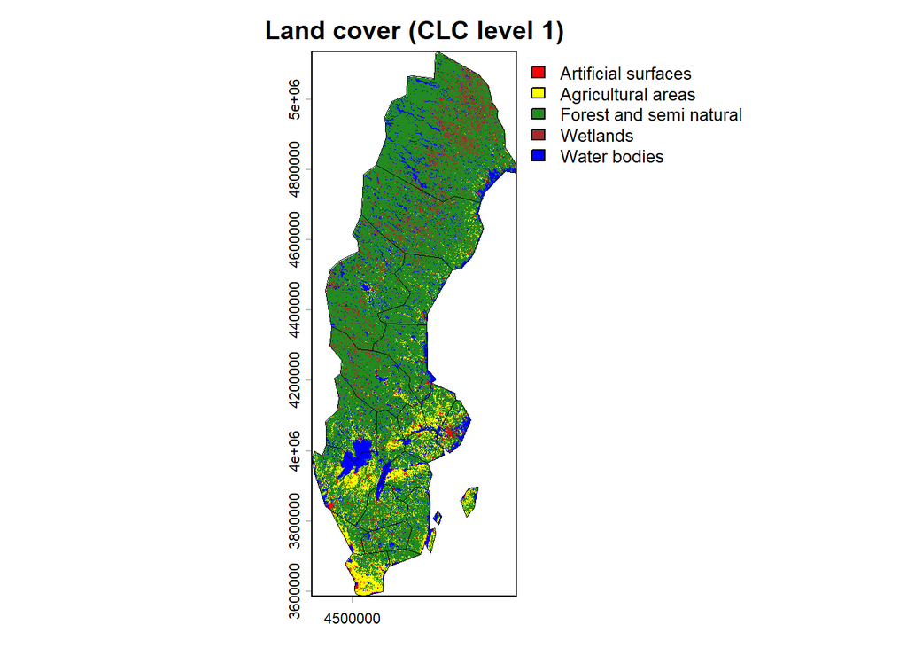

```r
names(lc_level1) <- "lc_level1"

levels(lc_level1) <- data.frame(
  id    = 1:5,
  class = c("Artificial surfaces", "Agricultural areas",
            "Forest and semi natural", "Wetlands", "Water bodies")
)
lc_cols <- c("red", "yellow", "forestgreen", "brown", "blue")

terra::plot(lc_level1, col = lc_cols, main = "Land cover (CLC level 1)")
terra::lines(nuts3_se, col = "black", lwd = 0.6)
```

```r
terra::freq(lc_level1)                             # exactly 5 classes and no NA row
```

```
##   layer                   value    count
## 1     1     Artificial surfaces   648754
## 2     1      Agricultural areas  3825045
## 3     1 Forest and semi natural 33344473
## 4     1                Wetlands  3032294
## 5     1            Water bodies  4662189
```

```r
# forest and vegetation = CLC GRID_CODE 23 to 29 (CLC 311-324)
forest_sn <- terra::classify(landcover, rcl = matrix(c(23, 29, 1), ncol = 3),
                             others = 0, right = NA)   # forest and semi natural = 1, other = 0
```

```
## |---------|---------|---------|---------|=========================================
```

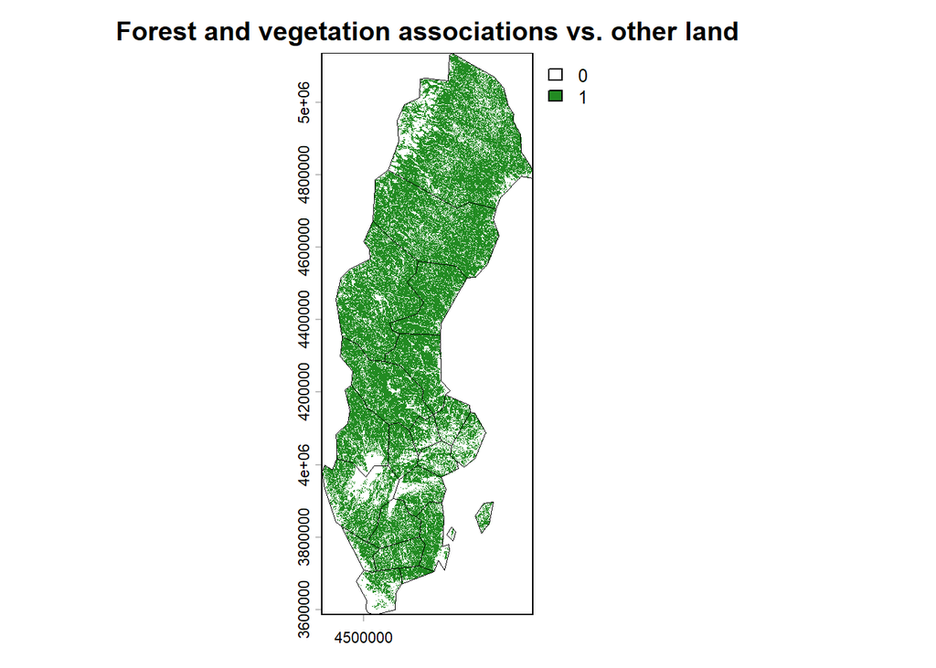

```r
names(forest_sn) <- "forest_sn"

terra::plot(forest_sn, col = c("white", "forestgreen"),
            main = "Forest and vegetation associations vs. other land")
terra::lines(nuts3_se, col = "black", lwd = 0.6)
```

```r
terra::freq(forest_sn)
```

```
##   layer value    count
## 1     1     0 13304814
## 2     1     1 32207941
```

## 4. Tick observations

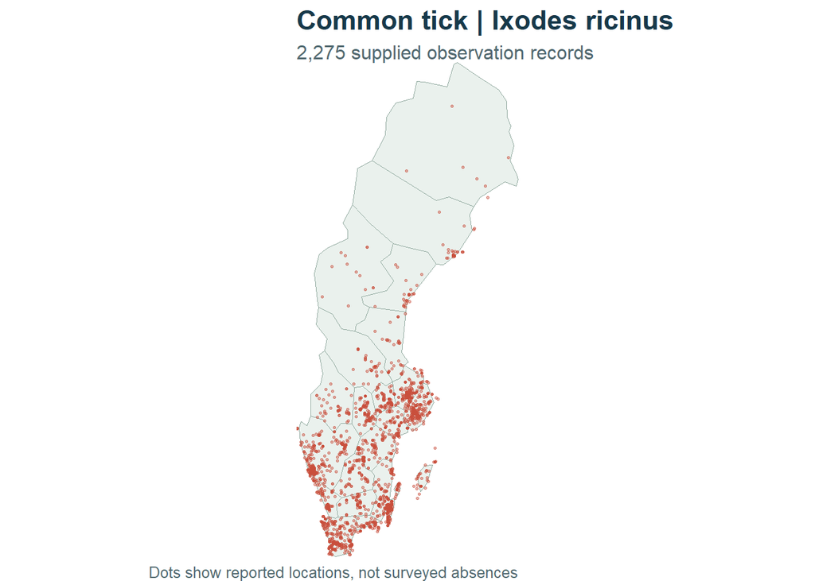

```r
records <- read.csv(file.path("data", tick$file), skip = 2, sep = ",",
                    fileEncoding = "latin1")           # header starts on line 3

stopifnot(all(c("Ost", "Nord") %in% names(records)))
records <- records[complete.cases(records[, c("Ost", "Nord")]), ]

observations <- sf::st_as_sf(records, coords = c("Ost", "Nord"), crs = 3021)
observations <- sf::st_transform(observations, 4326)

regions <- sf::st_transform(sf::st_read("data/Sweden_NUTS3.gpkg", quiet = TRUE), 4326)

tick_map <- ggplot() +
  geom_sf(data = regions, fill = "#EAF1ED",
          colour = "#91A99F", linewidth = 0.25) +
  geom_sf(data = observations, colour = "#C84E3B",
          alpha = 0.45, size = 0.55) +
  coord_sf(expand = FALSE, datum = NA) +
  labs(title = paste(tick$common, "|", tick$latin),
       subtitle = paste(format(nrow(records), big.mark = ","),
                        "supplied observation records"),
       caption = "Dots show reported locations, not surveyed absences") +
  theme_void(base_size = 12) +
  theme(plot.title = element_text(face = "bold", size = 17, colour = "#17394A"),
        plot.subtitle = element_text(colour = "#536A71"),
        plot.caption = element_text(colour = "#536A71"),
        plot.background = element_rect(fill = "white", colour = NA))

print(tick_map)
```

```r
ggsave(file.path(out_dir, "01_tick_observations.png"), plot = tick_map,
       width = 7, height = 8, dpi = 250, bg = "white")
```

## 5. Habitat suitability model (Maxnet)

```r
# label the land cover and a copy of one climate layer with explicit coordinate systems
terra::crs(forest_sn) <- "+proj=laea +lat_0=52 +lon_0=10 +x_0=4321000 +y_0=3210000 +ellps=GRS80 +units=m +no_defs"
climate_grid <- climate[[1]]                       # used only as the target grid
terra::crs(climate_grid) <- "+proj=longlat +datum=WGS84 +no_defs"

# share of forest and semi natural land in each climate cell (0 = none, 1 = all)
forest_grid <- terra::project(forest_sn, climate_grid, method = "average")
names(forest_grid) <- "forest_grid"

# one stack with all predictors; NA wherever land cover is missing
env <- terra::mask(c(climate, forest_grid), forest_grid)
names(env)
```

```
## [1] "bio1"        "bio12"       "bio15"       "forest_grid"
```

```r
xy <- as.data.frame(sf::st_coordinates(observations))
names(xy) <- c("x", "y")
presence <- as.data.frame(SDMtune::thinData(xy, env = env))    # at most one record per grid cell

background <- terra::spatSample(env[[1]], size = 2000,
                                method = "random", na.rm = TRUE,
                                xy = TRUE, values = FALSE)

cat("Original records:", nrow(records), "\n")
```

```
## Original records: 2275
```

```r
cat("Cells retained for modelling:", nrow(presence), "\n")
```

```
## Cells retained for modelling: 1133
```

```r
samples <- SDMtune::prepareSWD(species = tick$latin,
                               p = presence, a = background,
                               env = env)

# hold back 20% of presence cells for a predictive check
parts <- SDMtune::trainValTest(samples, test = 0.2,
                               only_presence = TRUE, seed = 42)

model <- SDMtune::train(method = "Maxnet", data = parts[[1]],
                        fc = "lq", reg = 1)                    # linear + quadratic features
model
```

[output not shown]

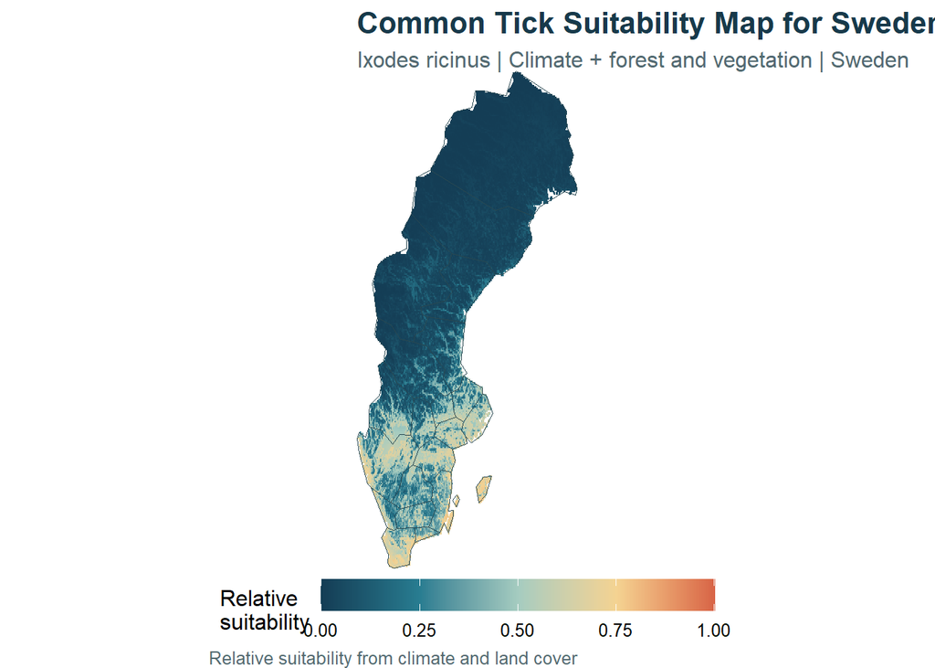

```r
suitability <- predict(model, data = env, type = "logistic")   # suitability score (0-1) per cell

palette <- c("#143D55", "#287D91", "#A5CCC0", "#F4D392", "#D76346")
map_cells <- as.data.frame(suitability, xy = TRUE, na.rm = TRUE)
names(map_cells)[3] <- "score"

suitability_map <- ggplot(map_cells, aes(x = x, y = y, fill = score)) +
  geom_raster() +
  geom_sf(data = sf::st_as_sf(nuts3_clim), inherit.aes = FALSE,
          fill = NA, colour = "#294851", linewidth = 0.25) +
  scale_fill_gradientn(colours = palette, limits = c(0, 1),
                       name = "Relative\nsuitability") +
  coord_sf(expand = FALSE, datum = NA) +
  labs(title = "Common Tick Suitability Map for Sweden",
       subtitle = paste(tick$latin, "| Climate + forest and vegetation | Sweden"),
       caption = "Relative suitability from climate and land cover") +
  theme_void(base_size = 12) +
  theme(plot.title = element_text(face = "bold", size = 16, colour = "#17394A"),
        plot.subtitle = element_text(colour = "#536A71"),
        plot.caption = element_text(colour = "#536A71"),
        legend.position = "bottom",
        legend.key.width = grid::unit(1.5, "cm"),
        plot.background = element_rect(fill = "white", colour = NA))

print(suitability_map)
```

```r
ggsave(file.path(out_dir, "02_suitability_climate_landcover.png"),
       plot = suitability_map, width = 8, height = 8, dpi = 250, bg = "white")
```

```r
train_auc <- SDMtune::auc(model)
test_auc  <- SDMtune::auc(model, test = parts[[2]])
cat(sprintf("Training AUC: %.3f | Held-out AUC: %.3f\n", train_auc, test_auc))
```

```
## Training AUC: 0.861 | Held-out AUC: 0.862
```

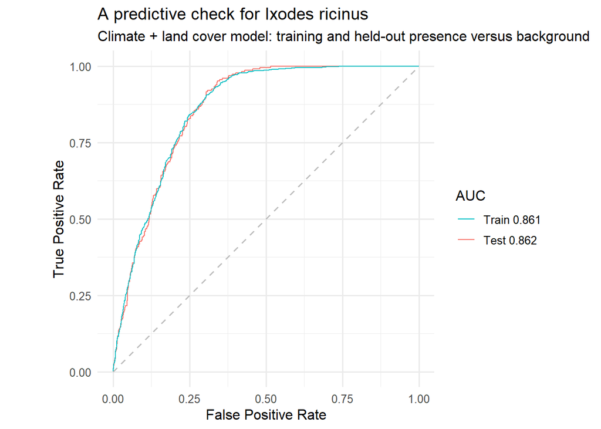

```r
roc_plot <- SDMtune::plotROC(model, test = parts[[2]]) +
  labs(title = paste("A predictive check for", tick$latin),
       subtitle = "Climate + land cover model: training and held-out presence versus background") +
  theme_minimal(base_size = 12)

print(roc_plot)
```

```r
ggsave(file.path(out_dir, "03_roc.png"), plot = roc_plot,
       width = 7, height = 5, dpi = 220, bg = "white")

vi <- SDMtune::varImp(model, permut = 5)           # contribution of each predictor
vi
```

```
##      Variable Permutation_importance    sd
## 1        bio1                   86.3 0.010
## 2 forest_grid                   11.8 0.006
## 3       bio12                    1.9 0.002
## 4       bio15                    0.0 0.000
```

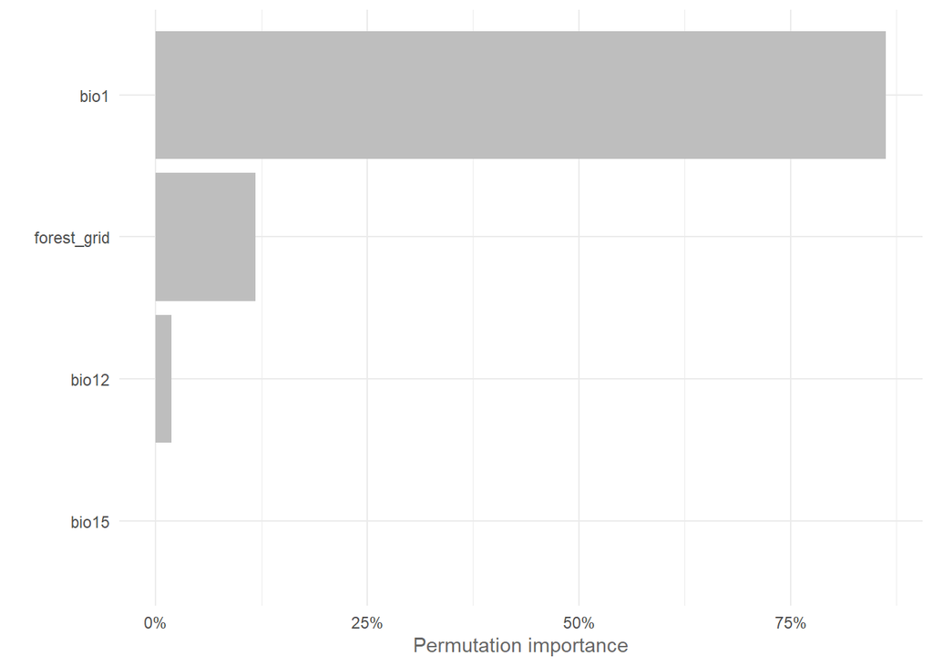

```r
SDMtune::plotVarImp(vi)
```

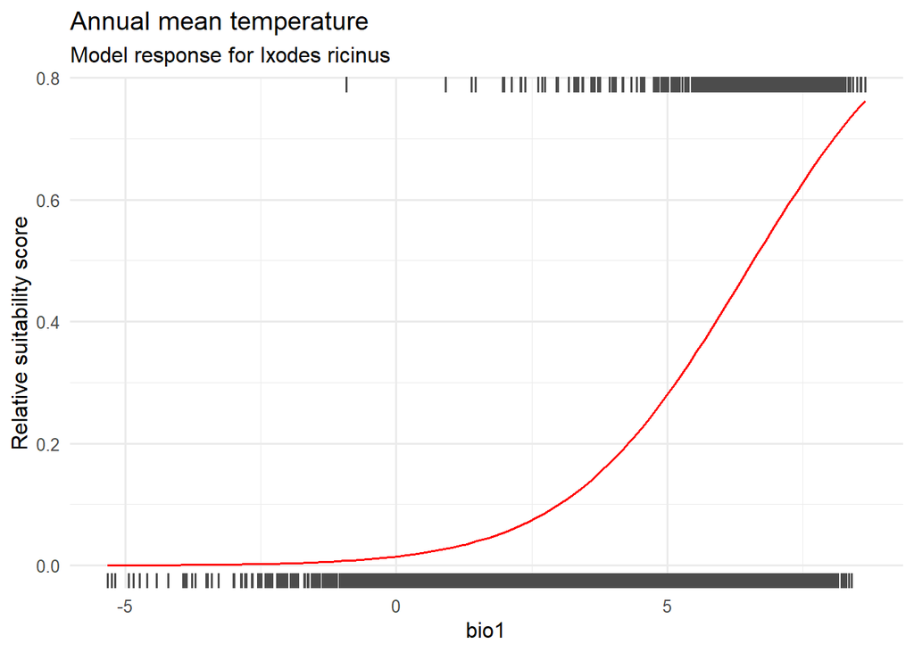

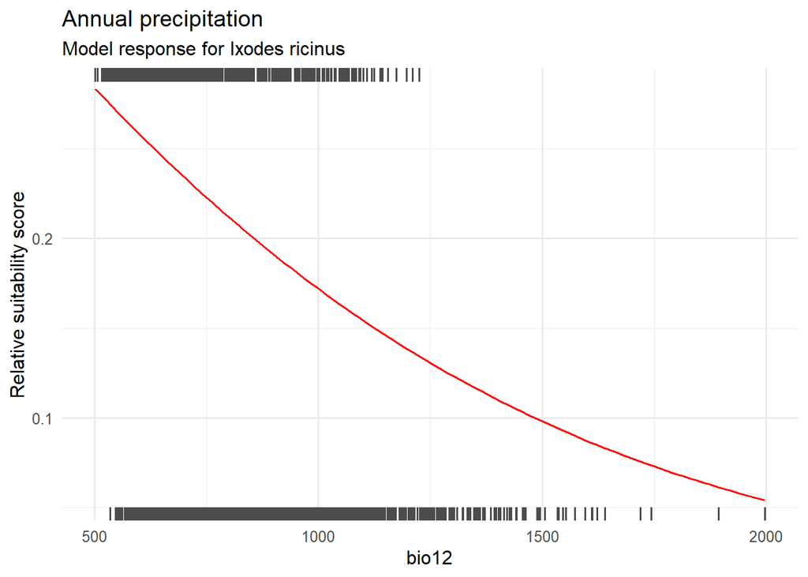

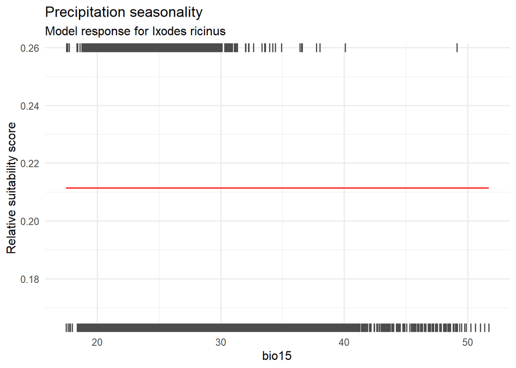

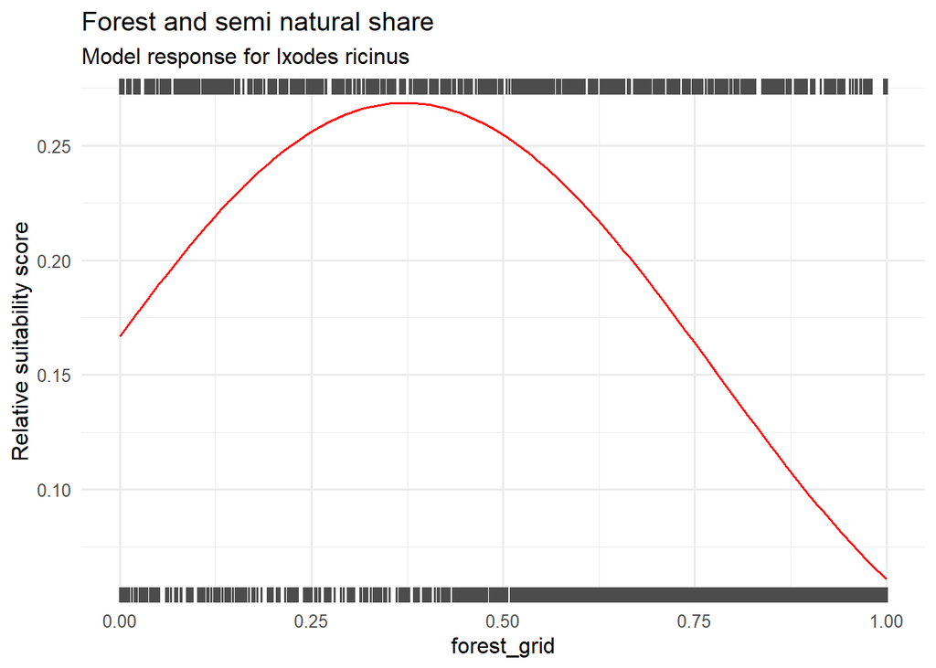

```r
response_labels <- c(bio1        = "Annual mean temperature",
                     bio12       = "Annual precipitation",
                     bio15       = "Precipitation seasonality",
                     forest_grid = "Forest and semi natural share")

for (v in names(env)) {
  response_plot <- SDMtune::plotResponse(
    model, var = v, type = "logistic",
    marginal = TRUE, rug = TRUE
  ) +
    labs(title = response_labels[[v]],
         subtitle = paste("Model response for", tick$latin),
         y = "Relative suitability score") +
    theme_minimal(base_size = 12)

  print(response_plot)
  ggsave(file.path(out_dir, paste0("response_", v, ".png")),
         plot = response_plot, width = 7, height = 4.5, dpi = 220)
}
```

## 6. Örebro län (SE124)

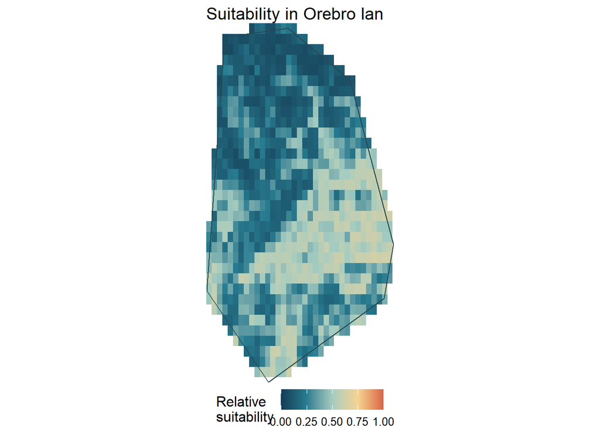

```r
# crop cuts the bounding box, mask removes cells outside the border
orebro <- nuts3_clim[nuts3_clim$NUTS_ID == "SE124", ]
stopifnot(nrow(orebro) == 1)

suitability_crop   <- terra::crop(suitability, orebro)
suitability_orebro <- terra::mask(suitability_crop, orebro)
names(suitability_orebro) <- "suitability"

orebro_cells <- as.data.frame(suitability_orebro, xy = TRUE, na.rm = TRUE)

orebro_map <- ggplot(orebro_cells, aes(x = x, y = y, fill = suitability)) +
  geom_raster() +
  geom_sf(data = sf::st_as_sf(orebro), inherit.aes = FALSE,
          fill = NA, colour = "#294851", linewidth = 0.5) +
  scale_fill_gradientn(colours = palette, limits = c(0, 1),
                       name = "Relative\nsuitability") +
  coord_sf(expand = FALSE, datum = NA) +
  labs(title = "Suitability in Orebro lan") +
  theme_void(base_size = 12) +
  theme(legend.position = "bottom",
        plot.background = element_rect(fill = "white", colour = NA))

print(orebro_map)
```

```r
ggsave(file.path(out_dir, "06_suitability_Orebro.png"), plot = orebro_map,
       width = 6, height = 6, dpi = 250, bg = "white")

terra::global(!is.na(suitability_orebro), "sum")   # number of cells with a value in Orebro
```

```
##             sum
## suitability 917
```

```r
res(suitability_orebro)                            # cell size in degrees
```

```
## [1] 0.04166667 0.04166667
```

```r
# forest layer cut to Orebro (same grid as suitability_orebro)
forest_orebro <- terra::mask(terra::crop(env[["forest_grid"]], orebro), orebro)

cells <- as.data.frame(c(suitability_orebro, forest_orebro), na.rm = TRUE)

# forest cells = at least 35 % forest share (state this in the report)
forest_threshold <- 0.35
forest_cells <- cells[cells$forest_grid >= forest_threshold, ]
nrow(forest_cells)
```

```
## [1] 784
```

```r
summary(terra::values(suitability_orebro, na.rm = TRUE))
```

```
##   suitability
##  Min.   :0.0539
##  1st Qu.:0.1634
##  Median :0.3062
##  Mean   :0.3220
##  3rd Qu.:0.4860
##  Max.   :0.6337
```

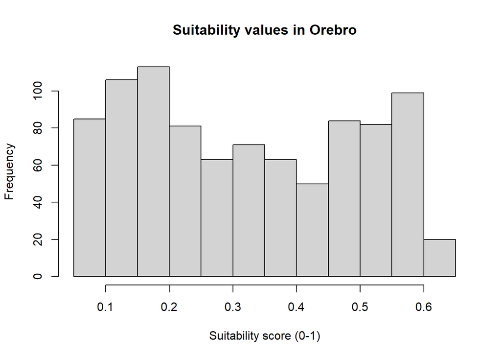

```r
hist(terra::values(suitability_orebro, na.rm = TRUE),
     breaks = 20,
     main = "Suitability values in Orebro",
     xlab = "Suitability score (0-1)")
```

## 7. Distribution of suitability (HSI) in Örebro forest cells

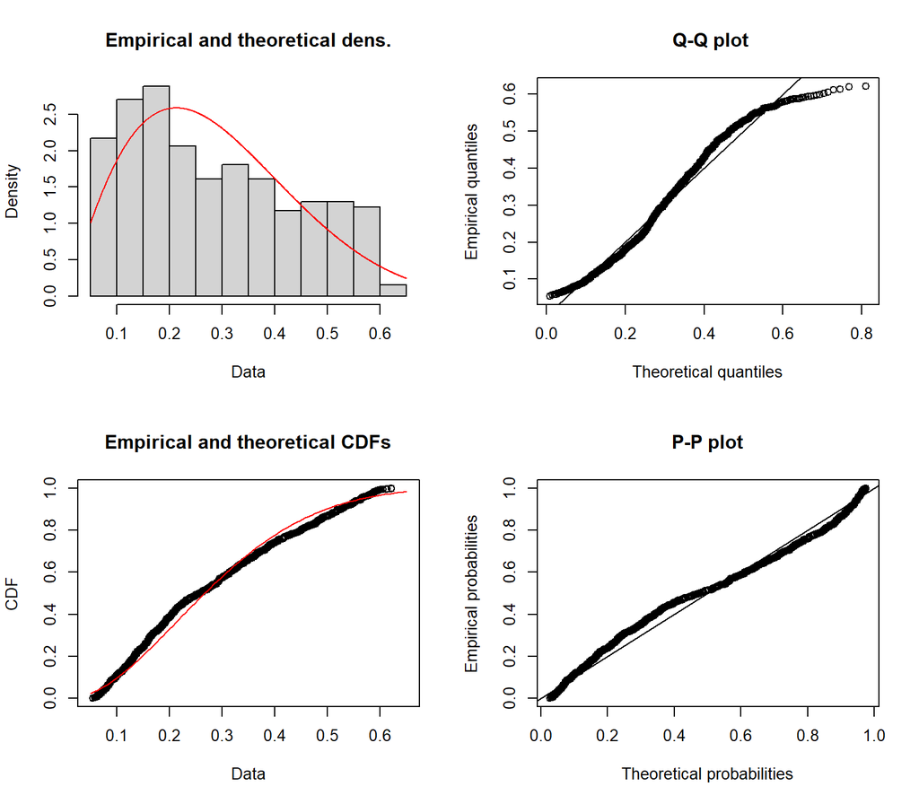

```r
# beta needs values strictly between 0 and 1
x <- pmin(pmax(forest_cells$suitability, 0.001), 0.999)

fit_beta <- fitdist(x, distr = "beta", method = "mle")
plot(fit_beta)
```

```r
fit_beta$estimate
```

```
##   shape1   shape2
## 2.252884 5.648795
```

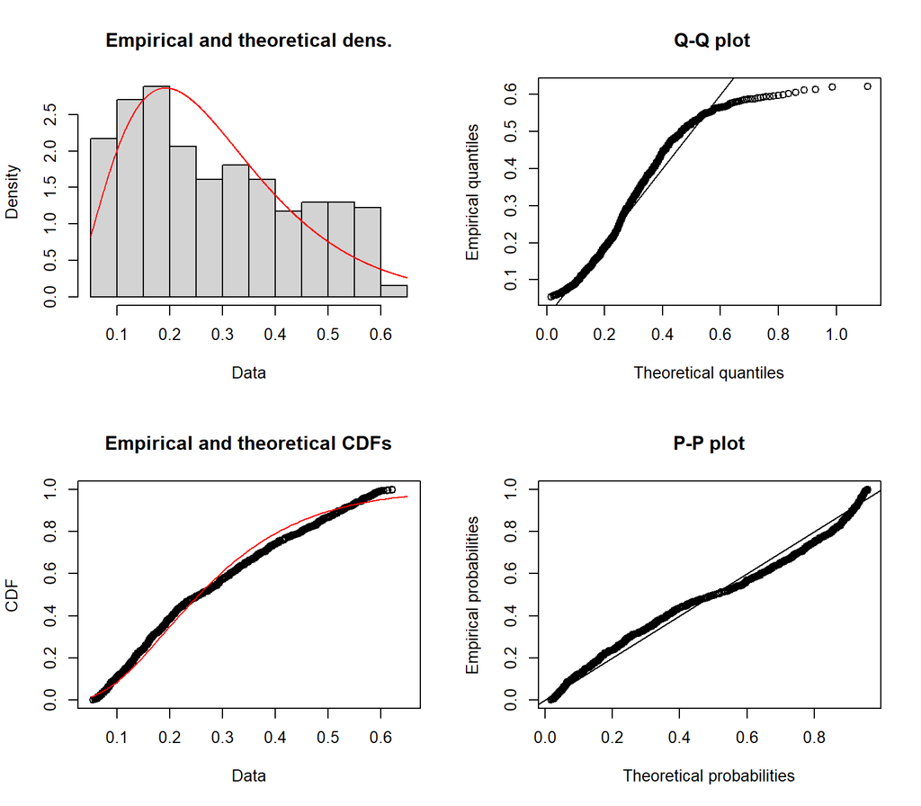

```r
fit_gamma <- fitdist(x, distr = "gamma", method = "mle")
plot(fit_gamma)
```

```r
fit_gamma$estimate
```

```
##     shape      rate
##  3.044589 10.682476
```

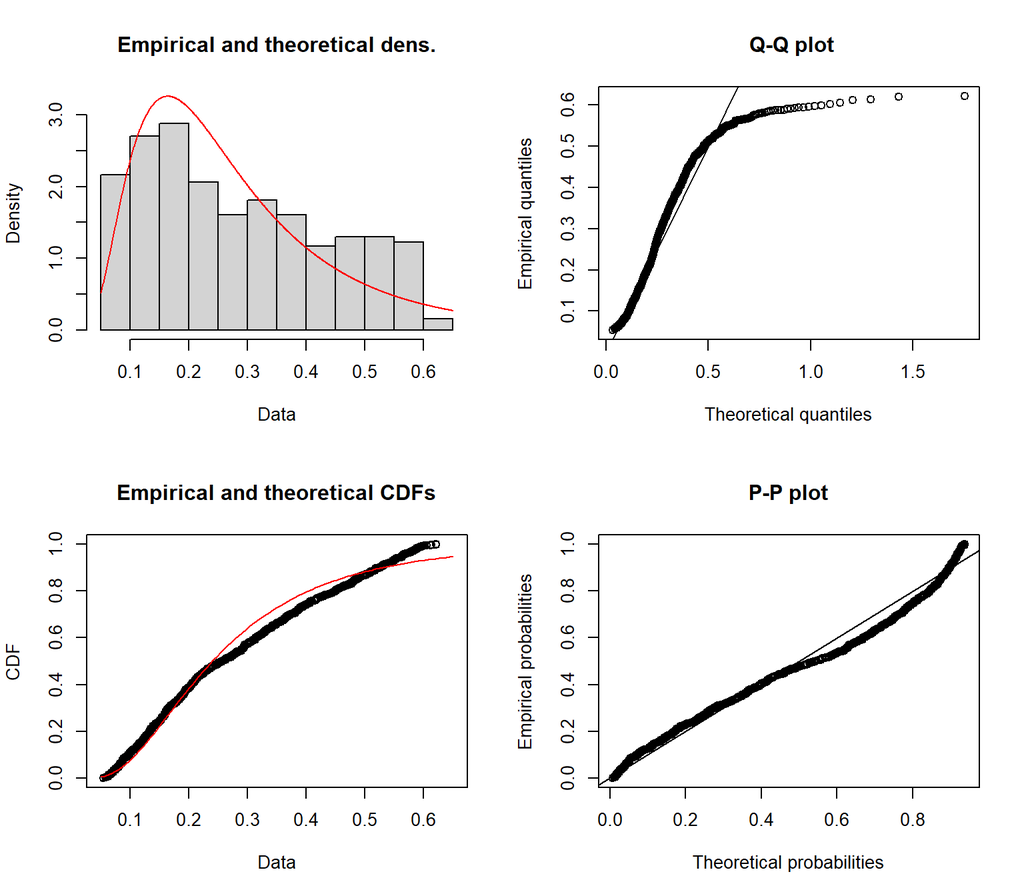

```r
fit_lnorm <- fitdist(x, distr = "lnorm", method = "mle")
plot(fit_lnorm)
```

```r
fit_lnorm$estimate
```

```
##    meanlog      sdlog
## -1.4283412  0.6184046
```

```r
# lower AIC = better fit
AIC(fit_beta)
```

```
## [1] -824.4433
```

```r
AIC(fit_gamma)
```

```
## [1] -798.4959
```

```r
AIC(fit_lnorm)
```

```
## [1] -764.3435
```

```r
shape1 <- fit_beta$estimate[["shape1"]]
shape2 <- fit_beta$estimate[["shape2"]]

# 95 % of forest cells have a suitability below this value
p95 <- qbeta(0.95, shape1 = shape1, shape2 = shape2)
p95
```

```
## [1] 0.5638269
```

```r
quantile(x, 0.95)                                  # check: empirical p95 should be close
```

```
##       95%
## 0.5634678
```

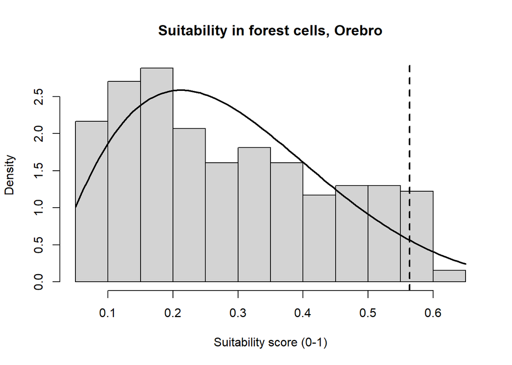

```r
draw_p95 <- function() {
  hist(x, breaks = 20, freq = FALSE,
       main = "Suitability in forest cells, Orebro",
       xlab = "Suitability score (0-1)")
  curve(dbeta(x, shape1, shape2), add = TRUE, lwd = 2)
  abline(v = p95, lty = 2, lwd = 2)
}
draw_p95()
```

```r
png(file.path(out_dir, "04a_p95_Orebro.png"), width = 7, height = 5, units = "in", res = 250)
draw_p95()
invisible(dev.off())
```

## 8. First assessment: single value

```r
# p(inf | forest, Orebro) = HSI x prevalence of infected ticks
low_prevalence     <- 0.0010   # 0.10 %  (Pettersson et al. 2014, lowest)
central_prevalence <- 0.0023   # 0.23 %  (Pettersson et al. 2014, central)
high_prevalence    <- 0.0055   # 0.55 %  (Pettersson et al. 2014, highest)

HSI <- p95                     # conservative HSI (95th percentile of the fitted beta)

p_inf_point <- HSI * central_prevalence
cat("HSI:", round(HSI, 4), "\n")
```

```
## HSI: 0.5638
```

```r
cat("Single value p(inf | forest, Orebro):", round(p_inf_point * 100, 3), "%\n")
```

```
## Single value p(inf | forest, Orebro): 0.13 %
```

## 9. Uncertainty

### 9.1 Bootstrap of the HSI distribution (cells) and prevalence

```r
set.seed(42)
boot_beta <- fitdistrplus::bootdist(fit_beta, bootmethod = "nonparam", niter = n_iter)

# conservative HSI (p95 of the fitted beta) for each resample
HSI_boot <- qbeta(0.95, boot_beta$estim$shape1, boot_beta$estim$shape2)

# prevalence uncertainty: uniform between low and high (Pettersson et al. 2014)
prevalence_draw <- runif(length(HSI_boot), low_prevalence, high_prevalence)

# Monte Carlo: multiply HSI sample and prevalence sample
p_inf_cell <- HSI_boot * prevalence_draw * 100     # in %

# which source contributes what
uncertainty_table <- rbind(
  HSI_only        = quantile(HSI_boot * central_prevalence * 100, q_probs),
  prevalence_only = quantile(median(HSI_boot) * prevalence_draw * 100, q_probs),
  both            = quantile(p_inf_cell, q_probs)
)
colnames(uncertainty_table) <- q_names
round(uncertainty_table, 3)
```

```
##                    P5   P25   P50   P75   P95
## HSI_only        0.126 0.128 0.130 0.131 0.133
## prevalence_only 0.068 0.117 0.181 0.244 0.296
## both            0.068 0.117 0.181 0.244 0.298
```

```r
write.csv(round(uncertainty_table, 4),
          file.path(out_dir, "uncertainty_sources_Orebro.csv"))
```

```r
# the prevalence draws used above, in %
prev_pct <- prevalence_draw * 100
q_prev <- quantile(prev_pct, q_probs)
names(q_prev) <- q_names
round(q_prev, 3)
```

```
##    P5   P25   P50   P75   P95
## 0.120 0.208 0.322 0.432 0.525
```

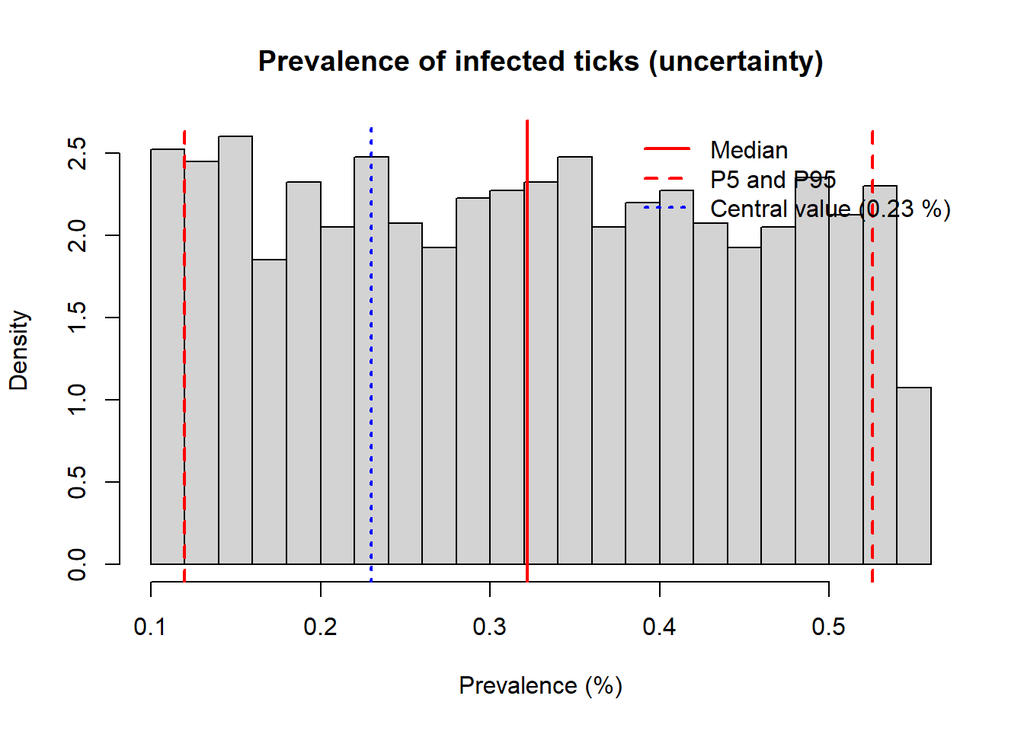

```r
draw_prev <- function() {
  hist(prev_pct, breaks = 30, freq = FALSE,
       main = "Prevalence of infected ticks (uncertainty)", xlab = "Prevalence (%)")
  abline(v = q_prev[c("P5", "P95")], col = "red", lty = 2, lwd = 2)
  abline(v = q_prev["P50"], col = "red", lty = 1, lwd = 2)
  abline(v = central_prevalence * 100, col = "blue", lty = 3, lwd = 2)
  legend("topright", legend = c("Median", "P5 and P95", "Central value (0.23 %)"),
         col = c("red", "red", "blue"), lty = c(1, 2, 3), lwd = 2, bty = "n")
}
draw_prev()
```

```r
png(file.path(out_dir, "08_prevalence_uncertainty.png"), width = 7, height = 5, units = "in", res = 250)
draw_prev()
invisible(dev.off())
```

### 9.2 Bootstrap of the Maxnet model

```r
# refit Maxnet on resampled presence records and new background points
n_boots   <- n_iter
boot_list <- vector("list", n_boots)

set.seed(42)
for (i in seq_len(n_boots)) {
  # 1. resample presence points with replacement
  boot_presence <- presence[sample(nrow(presence), replace = TRUE), ]

  # 2. new random background points
  boot_background <- terra::spatSample(env[[1]], size = 2000,
                                       method = "random", na.rm = TRUE,
                                       xy = TRUE, values = FALSE)

  # 3. prepare SWD object
  boot_samples <- SDMtune::prepareSWD(species = tick$latin,
                                      p = boot_presence,
                                      a = boot_background,
                                      env = env)

  # 4. train Maxnet on the bootstrapped data
  boot_model <- SDMtune::train(method = "Maxnet", data = boot_samples,
                               fc = "lq", reg = 1)

  # 5. predict suitability map for this iteration
  boot_list[[i]] <- predict(boot_model, data = env, type = "logistic")

  if (i %% 250 == 0) cat(sprintf("Completed bootstrap iteration %d of %d\n", i, n_boots))
}
```

```
## Completed bootstrap iteration 250 of 2000
```

```
## Completed bootstrap iteration 500 of 2000
```

```
## Completed bootstrap iteration 750 of 2000
```

```
## Completed bootstrap iteration 1000 of 2000
```

```
## Completed bootstrap iteration 1250 of 2000
```

```
## Completed bootstrap iteration 1500 of 2000
```

```
## Completed bootstrap iteration 1750 of 2000
```

```
## Completed bootstrap iteration 2000 of 2000
```

```r
boot_stack <- terra::rast(boot_list)
names(boot_stack) <- paste0("boot_", seq_len(n_boots))
```

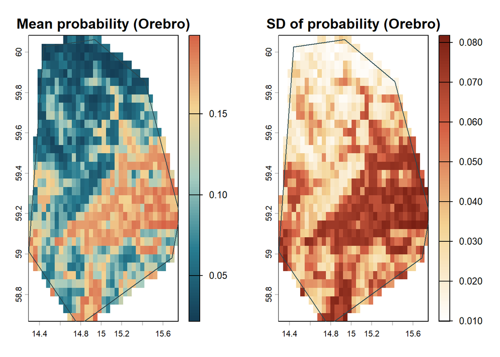

```r
# propagate the Maxnet bootstrap to Orebro maps (each map x one prevalence draw)
stopifnot(terra::nlyr(boot_stack) == n_iter)

boot_stack_orebro <- terra::mask(terra::crop(boot_stack, orebro), orebro)

set.seed(42)
prevalence_map_draw <- runif(terra::nlyr(boot_stack_orebro),
                             low_prevalence, high_prevalence)

p_inf_stack <- boot_stack_orebro * prevalence_map_draw * 100   # in %, layer-wise
p_inf_mean  <- terra::mean(p_inf_stack, na.rm = TRUE)
p_inf_sd    <- terra::stdev(p_inf_stack, na.rm = TRUE)

cols_prob <- colorRampPalette(c("#143D55", "#287D91", "#A5CCC0", "#F4D392", "#D76346"))(100)
cols_unc  <- colorRampPalette(c("white", "#F4D392", "#D76346", "#7A1F13"))(100)

draw_prob_maps <- function() {
  par(mfrow = c(1, 2))
  terra::plot(p_inf_mean, col = cols_prob, main = "Mean probability (Orebro)")
  terra::lines(orebro, col = "#294851", lwd = 1)
  terra::plot(p_inf_sd, col = cols_unc, main = "SD of probability (Orebro)")
  terra::lines(orebro, col = "#294851", lwd = 1)
  par(mfrow = c(1, 1))
}
draw_prob_maps()
```

```r
png(file.path(out_dir, "05_probability_maps_Orebro.png"),
    width = 10, height = 5, units = "in", res = 250)
draw_prob_maps()
invisible(dev.off())

terra::writeRaster(p_inf_mean, file.path(out_dir, "probability_mean_Orebro.tif"), overwrite = TRUE)
terra::writeRaster(p_inf_sd,   file.path(out_dir, "probability_sd_Orebro.tif"),   overwrite = TRUE)
```

## 10. Summary of the Monte Carlo result (input for the overall uncertainty judgement)

```r
# conservative HSI (p95 of forest cells) for each Maxnet bootstrap map
f <- terra::values(forest_orebro)[, 1]

HSI_boot_maxnet <- sapply(seq_len(terra::nlyr(boot_stack_orebro)), function(i) {
  v <- terra::values(boot_stack_orebro[[i]])[, 1]
  v <- v[!is.na(v) & !is.na(f) & f >= forest_threshold]
  unname(quantile(v, 0.95))
})

p_inf_maxnet <- HSI_boot_maxnet * prevalence_map_draw * 100    # in %

overall_table <- rbind(
  cell_bootstrap   = quantile(p_inf_cell,   q_probs),
  maxnet_bootstrap = quantile(p_inf_maxnet, q_probs)
)
colnames(overall_table) <- q_names

round(p_inf_point * 100, 3)                        # first assessment, single value (%)
```

```
## [1] 0.13
```

```r
round(overall_table, 3)
```

```
##                     P5   P25   P50   P75   P95
## cell_bootstrap   0.068 0.117 0.181 0.244 0.298
## maxnet_bootstrap 0.067 0.113 0.179 0.242 0.292
```

```r
# where the single value sits within the Maxnet bootstrap distribution
mean(p_inf_maxnet <= p_inf_point * 100)
```

```
## [1] 0.312
```

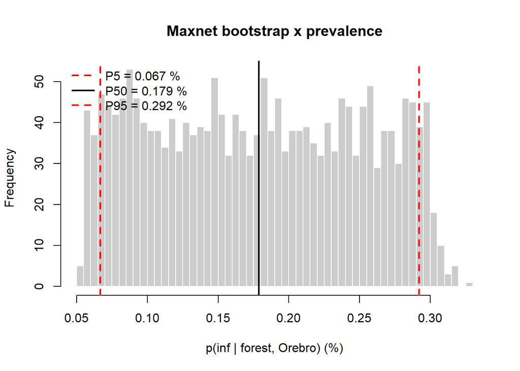

```r
write.csv(round(overall_table, 4),
          file.path(out_dir, "overall_quantiles_Orebro.csv"))

# histograms with P5, P50, P95
draw_prob_hist <- function(values, title) {
  q <- quantile(values, c(0.05, 0.50, 0.95))
  hist(values, breaks = 40, col = "grey80", border = "white",
       main = title, xlab = "p(inf | forest, Orebro) (%)")
  abline(v = q[c(1, 3)], col = "red", lty = 2, lwd = 2)
  abline(v = q[2],       col = "black", lwd = 2)
  legend("topleft", bty = "n",
         legend = c(paste0("P5 = ",  round(q[1], 3), " %"),
                    paste0("P50 = ", round(q[2], 3), " %"),
                    paste0("P95 = ", round(q[3], 3), " %")),
         col = c("red", "black", "red"), lty = c(2, 1, 2), lwd = 2)
}

draw_prob_hist(p_inf_maxnet, "Maxnet bootstrap x prevalence")
```

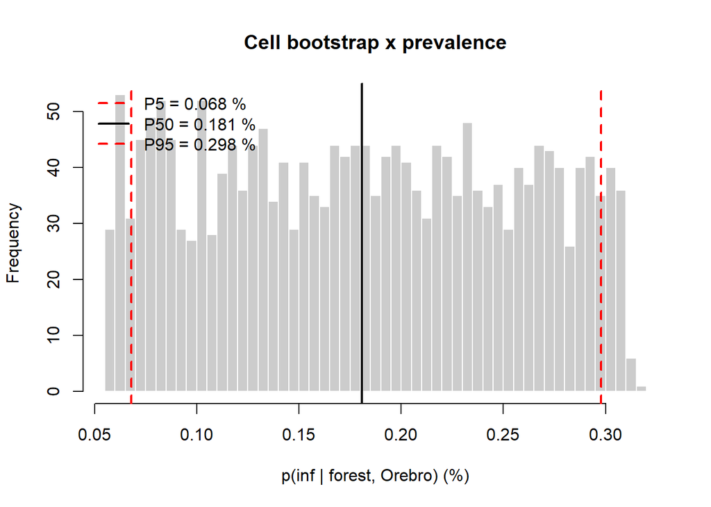

```r
png(file.path(out_dir, "04_probability_histogram_maxnet_Orebro.png"),
    width = 7, height = 5, units = "in", res = 250)
draw_prob_hist(p_inf_maxnet, "Maxnet bootstrap x prevalence")
invisible(dev.off())

draw_prob_hist(p_inf_cell, "Cell bootstrap x prevalence")
```

```r
png(file.path(out_dir, "04b_probability_histogram_cell_Orebro.png"),
    width = 7, height = 5, units = "in", res = 250)
draw_prob_hist(p_inf_cell, "Cell bootstrap x prevalence")
invisible(dev.off())
```